# 1. 소개

NLP는 언어학 지식에 상관없이 텍스트를 이해하는 통계적인 방법을 사용해 실전 문제를 해결하는 일련의 기술을 말한다.

텍스트 이해는 주로 **텍스트를 계산 가능한 표현**으로 변환함으로서 이루어진다. 이 표현은 벡터, 텐서, 그래프, 트리 같이 이산적이거나 연속적으로 조합한 구조이다.

데이터에서 작업에 알맞은 표현을 학습하는 일은 **머신러닝**의 한 분야. 최근 10년 동안 **딥러닝**이라는 머신러닝 기술이 발전을 거듭하여 NLP, 음성, CV 여러 가지 인공 지능 작업에서 효과성을 입증받기 시작했다.

딥러닝은 **계산 그래프와 수치 최적화 기술**을 사용해 데이터에서 표현을 효과적으로 학습하는 기술이다. 이 책은 파이토치를 사용하는데, 파이토치는 딥러닝 알고리즘을 구현하는 파이썬 기반의 계산 그래프 프레임워크로 인기가 점점 높아지고 있다.

이 책은 주로 **지도 학습**을 다루는데, 지도 학습은 **레이블된 훈련 샘플로 학습**한다.

이 장의 목표는 다음과 같다.

- 지도 학습을 완전히 이해하고 용어를 익힌다. 앞으로 다룰 학습 과제의 기초가 되는 개념을 정립한다.
- 머신러닝 문제에 맞도록 입력을 인코딩하는 방법을 배운다.
- 계산 그래프가 무엇인지 이해한다.
- 파이토치의 기본을 숙달한다.

## 지도 학습

지도 학습은 **샘플에 대응하는 타깃의 정답**을 제공하는 방식을 말한다.

문서 분류 작업에서 샘플은 문서이고, 타깃은 범주형 레이블이다. 기계 번역에서 샘플은 한 언어의 문장이고 타깃은 다른 언어의 문장이다. 입력 데이터에 대한 이해를 바탕으로 지도 학습 시스템을 다음과 같이 표현할 수 있다.

**샘플**

샘플은 예측에 사용하는 아이템이다. 샘플은 $x$로 표시한다. 이따금 샘플을 **입력**이라고 부른다.

**타깃**

타깃은 샘플에 상응하는 레이블이며, 일반적으로 예측되는 대상이다. ML/DL의 표준적인 표기법에 따라 $y$로 나타낸다. 이따금 레이블을 **정답**이라고 부른다.

**모델**

모델은 수학식이나 샘플 $x$를 받아 타깃 레이블값을 예측하는 함수이다.

**파라미터**

파라미터는 이따금 **가중치**라고도 부른다. 파라미터가 모델을 규정한다. 기본적으로 가중치를 의미하는 $w$을 사용한다.

**예측**

예측은 모델이 추측하는 타깃. **추정**이라고도 함. 'hat' 표기를 사용하며, 타깃 $y$의 예측은 $\hat y$라고 표현한다.

**손실 함수**

손실 함수는 훈련 데이터에 대한 예측이 타깃과 얼마나 멀리 떨어져 있는지 비교하는 함수이다. 타깃과 예측이 주어지면 손실 함수는 **손실이라 부르는 실수 스칼라값**을 계산한다. 손실이 낮을수록 타깃 예측을 더 잘하는 모델이다. 손실 함수는 $L$로 표기한다.

샘플 $n$개로 이루어진 $D = (X_i, y_i)_{i=1}^{n}$가 있다고 가정했을 때, 이런 데이터셋이 주어질 때 가중치 $w$을 파라미터로 받는 함수 $f$를 학습하려 한다. 즉 우리가 가정한 $f$ 구조 하에서 학습된 가중치 $w$의 값이 모델을 완전하게 설명할 것이다. 모델은 **주어진 입력 $X$에 대한 타깃 $\hat y$를 예측**한다.

$$\hat y = f(X, w)$$

**지도 학습에서는 훈련 샘플의 진짜 타깃 $y$를 안다. 이 샘플의 손실은 $L(y, \hat y)$이다.** 지도 학습은 샘플 $n$개 전체의 누적 손실을 최소화하는 최적의 파라미터 또는 가중치 $w$을 찾는 과정이다.

### 확률 경사 하강법을 사용한 훈련

경사 하강법은 파라미터의 초깃값을 추측한 다음 목적 함수의 값이 수용할만할 임계점 아래로 내려갈 때까지 파라미터를 반복해서 업데이트한다. 데이터셋이 크면 메모리 제약 때문ㅇ ㅔ전체 데이터셋을 사용하는 전통적인 경사 하강법을 적용하기 어렵다.

따라서 경사 하강법 대신 근사 버전인 **확률적 경사 하강법(SGD)**를 사용한다. 확률적인 방법에서는 데이터 포인트를 하나 또는 일부 랜덤하게 선택하여 gradient를 계산한다. 데이터 포인트를 하나 사용하는 방법은 순수 SGD, 두 개 이상 사용하는 방법은 **미니배치 SGD**라고 부른다. 실전에서는 미니배치 SGD를 자주 사용한다.

한 편, 파라미터를 반복적으로 업데이트하는 과정을 **역전파**라고 부르며, 역전파의 각 단계(epoch)는 정방향 계산광 역방향 계산으로 구성된다. 정방향 계산은 현재 파라미터 값으로 입력을 평가하여 손실 함수를 계산한다. 역방향 계산은 손실의 gradient을 사용하여 파라미터를 업데이트한다.

## 샘플과 타깃의 인코딩

수치 벡터는 텍스트를 표현하는 간단한 방법. 이런 매핑이나 표현을 수행하는 방법은 수없이 많다.

여기에서는 휴리스틱 기반의 간단한 카운트 방식 표현으로 시작해 보겠다. 카운트 기반 표현은 **모두 고정된 차원의 벡터**로 시작한다.

### 원-핫 표현

**원-핫 표현**은 0 벡터에서 시작해 문장이나 문서에 등장하는 단어에 상응하는 원소를 1로 설정한다. 다음 두 문장의 예시를 보자.

Time flies like an arrow.

Fruit flies like a banana.

문장을 토큰으로 나누고 구두점을 무시한 다음 모두 소문자로 바꾸면 어휘 사전 크기는 다음과 같이 8이 된다.

{time, fruit, flies, like, a, an, arrow, banana} 이다. 따라서 각 단어를 **8차원 원-핫 벡터로 표현**할 수 있다.

이러한 인코딩을 사용하면 'like a banana'의 원-핫 표현은 3x8 크기의 행렬이 된다.

텍스트/구를 어휘 사전 크기의 벡터 크기 하나로 표현하는 이진 인코딩도 종종 볼 수 있다. 여기서 0과 1이 한 단어의 등장 여부를 나타낸다. 'like a banana'의 이진 이코딩은 [0,0,0,1,1,0,0,1]이다.

이 책에서는 입력으로 거의 원-핫 표현만 사용하지만 문서 빈도와 TF-IDF 표현도 잠시 소개하겠다.

### TF 표현

구, 문장, 문서의 TF 표현은 단순히 소속 단어의 원-핫 표현을 합해 만든다. 예를 들어 앞에서 언급한 원-핫 인코딩 방식을 사용한 'Fruit flies like time flies a fruit'의 TF 표현은 다음과 같다.

$$[1,2,2,1,1,0,0,0]$$

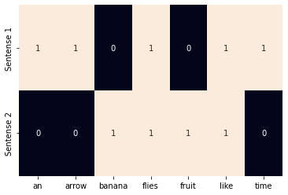

```python
# 사이킷런을 이용하여 원-핫 벡터 또는 이진 표현 만들기

from sklearn.feature_extraction.text import CountVectorizer
import seaborn as sns

corpus = ['Time flies like an arrow.', 'Fruit flies like a banana.']
one_hot_vectorizer = CountVectorizer(binary = True)
one_hot = one_hot_vectorizer.fit_transform(corpus).toarray()
vocab = one_hot_vectorizer.get_feature_names_out()
sns.heatmap(one_hot, annot = True, cbar = False, xticklabels=vocab, yticklabels=['Sentense 1', 'Sentense 2'])
```

### TF-IDF 표현

문서 묶음이 있다고 가정해보자. 문서 대부분에 'claim', 'system', 'method', 'procedure' 같은 단어가 여러 번 반복해서 나올 것이라고 예상할 수 있다. TF는 등장 횟수에 비례하여 단어에 가중치를 부여한다.

하지만 'claim' 같이 흔한 단어에는 특정 특허와 관련된 어떤 정보도 담겨있지 않다. 반대로 희귀한 단어는 자주 나오지 않지만 특허 문서의 특징을 잘 나타낸다. 이런 상황에서는 **역문서 빈도**사 적합하다.

IDF는 벡터 표현에서 흔한 토큰의 점수를 낮추고, **드문 토큰의 점수를 높인다**. 토큰 $w$의 $IDF(w)$는 말뭉치 하나를 다음과 같이 정의한다.

$$IDF(w) = log \frac{N}{n_w}$$

$n_w$은 단어 $w$를 포함한 문서의 개수이고 $N$은 전체 문서의 개수이다. TF-IDF 점수는 TF와 IDF를 곱한 $TF(w) * IDF(w)$이다. 모든 문서에 등장하는 (즉 $n_w = N) 매우 흔한 단어는 $IDF(w) =0, TF-IDF = 0$이다. 따라서 이 단어를 완전히 제거한다.

반면 한 문서에만 등장하는 것처럼 아주 드물면 IDF는 최댓값 $log N$이 된다.

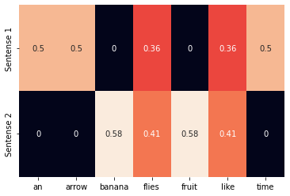

```python
# 사이킷런을 사용해 TF-IDF 표현 만들기

from sklearn.feature_extraction.text import TfidfVectorizer
import seaborn as sns

tfidf_vectorizer = TfidfVectorizer()
tfidf = tfidf_vectorizer.fit_transform(corpus).toarray()
sns.heatmap(tfidf, annot = True, cbar = False, xticklabels=vocab, yticklabels=['Sentense 1', 'Sentense 2'])
```

딥러닝의 목적은 표현 학습이므로 보통 TF-IDF와 같이 경험적인 방법으로 입력을 인코딩하지 않는다. 주로 정수 인덱스를 이용한 원-핫 인코딩과 특수한 임베딩 룩업 층으로 신경망의 입력을 구성한다.

### 타깃 인코딩

타깃 변수의 정확한 형태는 풀려는 NLP 문제에 따라 다르다. 예를 들어 기계 번역, 요약, 질의응답 문제에서는 타깃도 텍스트이며 앞서 설명한 원-핫 인코딩과 같은 방식으로 인코딩한다.

많은 NLP 작업은 범주형 레이블을 사용한다. 모델은 고정된 한 세트의 레이블 중 하나를 예측해야 한다. 이를 인코딩할 때는 레이블만다 고유한 인덱스를 부여하는 방법을 가장 많이 사용한다. 하지만 이런 간단한 표현은 출력 레이블 수가 너무 커지면 문제가 된다. 이전에 본 단어를 입력하면 다음 단어를 예측하는 언어 모델링이 그런 예이다. 레이블 규모가 한 언어의 전체 어휘가 되는데, 특수 문자, 이름 등을 포함하여 금방 수십만 개로 늘어날 수 있다.

일부 NLP 문제는 주어진 텍스트에서 수치를 예측한다. 예를 들어 어떤 수필에 숫자 등급이나 가독성 점수를 매겨야 하거나, 음식점 리뷰의 소수점 첫째 자리까지 평점을 예측해야 할 수 있다. 트윗 문장을 보고 사용장의 연령대를 예측해야 할 수도 이싿.

수치 타깃을 인코딩하는 방법은 몇 가지가 있다. 간단히 타깃을 **숫자의 구간으로 바꾸고 순서가 있는 분류 문제로 다루는 방법**이 있다. 구간은 균등하지 않아도 되며, 데이터에 따라 나눌 수 있다. 이런 경우 타깃 인코딩이 성능에 아주 큰 영향을 미친다.

## 계산 그래프

모델은 입력을 변환해서 예측을 얻는다. 손실 함수는 모델의 파라미터를 조정하는 피드백 신호를 제공하낟.

계산 그래프 데이터 구조를 사용하면 이런 데이터 흐름을 간편하게 구현할 수 있다. 기술적으로 보면 계산 그래프는 수학식을 추상적으로 모델링한 것이다. 딥러닝에서는 씨아노, 텐서플로, 파이토치와 같은 **계산 그래프의 구현이 부가적으로 자동 미분을 구현**한다. 자동 미분은 지도 학습 시스템에서 훈련하는 동안 파라미터의 gradient를 얻는 데 필요하다.

$$y = wx + b$$

이 식은 $z = wx$와 $y = z+b$로 나누어 쓸 수 있다. 그다음 유향 비순환 그래프를 이용하여 원래 식을 표현할 수 있다.

이 그래프의 **노드**는 곱셈이나 덧셈 같은 수학 연산을 나타낸다. 연산의 입력은 노드로 들어가는 **에지**이고, 연산의 출력은 노드에 나가는 에지이다. 식의 계산 그래프는 다음과 같다.

다음 절에서는 파이토치를 이용해 계산 그래프를 손쉽게 만드는 방법을 알아보겠다. 또한 gradient를 어떻게 자동으로 계산하는지 살펴보겠다.

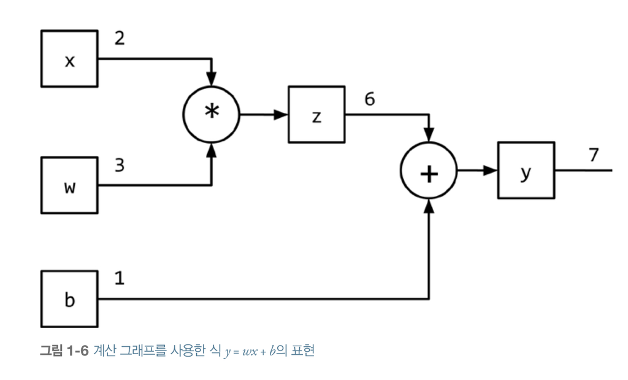

## 파이토치 기초

이 책은 파이토치를 사용해서 딥러닝 모델을 만든다. 파이토치는 테이프 기반 자동 미분 방식을 구현한다. 이 방식은 계산 그래프를 동적으로 정의하고 실행할 수 있다. 디버깅이 아주 편리하며 복잡한 모델을 손쉽게 만들 수 있게 한다.

씨아노, 카페, 텐서플로 같은 정적 프레임워크는 먼저 계산 그래프를 정의하고 컴파일한 다음 실행해야 한다. 체이너, 다이넷, 파이토치와 같은 프레임워크는 동적 계산 그래프를 구현하여 좀 더 유연한 명령형 스타일의 개발을 지원하며 **실행할 때마다 모델을 컴파일하지 않아도 된다**. 동적 계산 그래프는 특히 입력마다 다른 그래프 구조가 만들어질 수 있는 NLP 모델링 작업에 잘 맞는다.

파이토치는 다양한 딥러닝용 패키지를 제공하는 최적화된 텐서 조작 라이브러리이다. 파이토치의 핵심은 **텐서**이다. 텐서는 다차원 데이터를 담은 수학 객체이다.

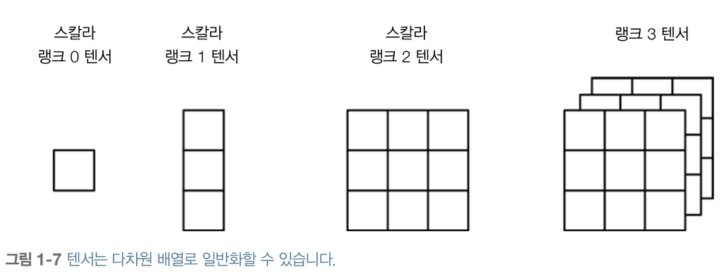

이 점에서 파이토치를 처음 사용해 보면서 다음과 같은 파이토치 연산을 배워볼 것이다.

- 텐서 만들기
- 텐서로 연산하기
- 텐서로 인덱싱, 슬라이싱, 연결하기
- 텐서로 gradient 계산하기.
- GPU와 함께 CUDA 텐서 사용하기.

### 텐서 만들기

먼저 헬퍼 함수 describe(x)를 정의한다. 텐서 타입, 차원, 값과 같은 텐서의 속성을 출력한다.

```python
def describe(x):
    print("타입 : {}".format(x.type())) # 배열 타입 출력
    print("크기 : {}".format(x.shape)) # 형상 출력
    print("값: \n{}".format(x)) # 값
```

파이토치에서는 torch 패키지를사용해 다양한 방법으로 텐서를 만들 수 있다. 우선 다음과 같이 차원을 지정하여 **텐서를 랜덤하게 초기화하는 방법**이 있다.

```python
import torch
describe(torch.Tensor(2,3))
```

```
타입 : torch.FloatTensor
크기 : torch.Size([2, 3])
값:
tensor([[ 0.0000e+00,  2.0000e+00, -9.4032e+28],
        [-3.6902e+19,  2.8131e+20,  1.7566e+25]])
```

[0, 1)의 균등 분포에서 샘플링한 값으로 랜덤하게 초기화한 텐서를 만들 수도 있다. 또는 아래처럼 정규 분포에서 텐서를 만들 수 있다.

```python
describe(torch.rand(2,3)) # 균등 분포
```

```
타입 : torch.FloatTensor
크기 : torch.Size([2, 3])
값:
tensor([[0.2378, 0.6289, 0.8452],
        [0.9565, 0.5189, 0.4706]])
```

```python
describe(torch.randn(2,3)) # 표준 정규 분포
```

```
타입 : torch.FloatTensor
크기 : torch.Size([2, 3])
값:
tensor([[-0.4573,  2.9082, -0.7508],
        [ 0.3918, -0.0531, -0.4812]])
```

동일한 스칼라값으로 채운 텐서를 만들 수 있다.

```
이는 fill_() 메서드를 사용해서 만들며, 밑줄 문자(_)가 있는 파이토치 in-place 메서드는 **텐서값을 바꾸는 연산**을 의미한다.
```

즉 아래 코드처럼 **새로운 객체를 만들지 않고 현잿값을 변경**한다.

```python
describe(torch.zeros(2,3)) # 0으로 채운 2*3 torch 생성
x = torch.ones(2,3)
describe(x)
```

```
타입 : torch.FloatTensor
크기 : torch.Size([2, 3])
값:
tensor([[0., 0., 0.],
        [0., 0., 0.]])
타입 : torch.FloatTensor
크기 : torch.Size([2, 3])
값:
tensor([[1., 1., 1.],
        [1., 1., 1.]])
```

```python
x.fill_(4) # x를 다른 객체 생성없이 4로 채워서 바꾸어라.
```

```
tensor([[4., 4., 4.],
        [4., 4., 4.]])
```

아래 코드는 Python list를 이용해 텐서를 만드는 방법을 보여준다.

```python
x = torch.tensor([[1, 2,3], [4,5,6]]) # np.array를 만드는 것과 완전히 같다.
describe(x)
```

```
타입 : torch.LongTensor
크기 : torch.Size([2, 3])
값:
tensor([[1, 2, 3],
        [4, 5, 6]])
```

위에서처럼 값은 리스트로 전달하거나, numpy 배열로 전달할 수 있다.

물론 언제든지 파이토치 텐서를 넘파이 배열로 바꿀 수 있다. 넘파이 배열을 사용하면 텐서 타ㅇ입이 기본 FloatTensor가 아닌, DoubleTensor가 된다.

```python
import numpy as np
npy = np.random.rand(2,3) # 균일분포. 파이토치와 생성하는 법이 같다.
describe(torch.from_numpy(npy))
```

```
타입 : torch.DoubleTensor
크기 : torch.Size([2, 3])
값:
tensor([[0.4992, 0.1016, 0.6305],
        [0.9253, 0.5091, 0.6891]], dtype=torch.float64)
```

넘파이 배열과 파이토치 텐서 사이를 변환하는 기능은 넘파이 포맷의 수치 데이터를 사용하는 legacy 라이브러리를 사용할 때 중요하다.

### 텐서 타입과 크기

텐서에는 타입과 크기가 있다. torch.Tensor 생성자를 사용할 때 기본 텐서 타입은 torch.FloatTensor이다.

텐서 타입은 초기화할 때 지정하거나, 나중에 타입 캐스팅 메서드를 사용해 다른 타입(float, long, double 등)으로 바꿀 수 있다.

초기화할 때 타입을 지정하는 방법은 두 가지 이다.

1. FloatTensor와 LongTensor 같은 특정 텐서 타입의 생성자를 직접 호출
2. torch.tensor() 메서드와 dtype 매개변수를 사용하는 방법

```python
# 특정 텐서 타입의 생성자 호출

x = torch.FloatTensor([[1,2,3], [4,5,6]])
describe(x)
```

```
타입 : torch.FloatTensor
크기 : torch.Size([2, 3])
값:
tensor([[1., 2., 3.],
        [4., 5., 6.]])
```

```python
x = x.long() # FloatTensor에서 LongTensor로 변환
describe(x)
```

```
타입 : torch.LongTensor
크기 : torch.Size([2, 3])
값:
tensor([[1, 2, 3],
        [4, 5, 6]])
```

64비트 integer은 LongTensor를, 32비트 float는 FloatTensor를 사용한다. 64비트 float는 DoubleTensor, 32비트 integer은 IntTensor

```python
# dtype 설정

x = torch.tensor([[1,2,3], [4,5,6]], dtype=torch.int64) # numpy와 완전히 똑같다.
describe(x)

## 주의해야 할 점 : torch.tensor와 torch.Tensor는 다르다. dtype을 설정할 때는 torch.tensor로 해주자.
## torch.Tensor는 32 bit floating point가 데이터 타입이다.
```

```
타입 : torch.LongTensor
크기 : torch.Size([2, 3])
값:
tensor([[1, 2, 3],
        [4, 5, 6]])
```

```python
x = x.float() # 마찬가지로 메서드 float()을 호출해 dtype을 변경할 수 있다.
describe(x)
```

```
타입 : torch.FloatTensor
크기 : torch.Size([2, 3])
값:
tensor([[1., 2., 3.],
        [4., 5., 6.]])
```

텐서 객체의 shape 속성과 size() 메서드를 이용해 텐서의 차원을 확인할 수 있다.

파이토치 코드를 디버깅할 때는 **꼭 텐서 크기를 조사해볼 것**을 추천한다.

### 텐서 연산

텐서를 만든 후 일반적인 프로그래밍 언어처럼 연산을 수행할 수 있다.

당연히, 연산자 대신에 이에 대응하는 .add() 같은 함수를 사용해도 된다.

```python
# add로 연산

x = torch.randn(2, 3)
addition = torch.add(x, x)
describe(addition)
```

```
타입 : torch.FloatTensor
크기 : torch.Size([2, 3])
값:
tensor([[-0.2790,  0.3696,  0.4260],
        [ 0.5566, -2.1186, -1.0192]])
```

```python
# 연산자로 연산
describe(x + x)
```

```
타입 : torch.FloatTensor
크기 : torch.Size([2, 3])
값:
tensor([[-0.2790,  0.3696,  0.4260],
        [ 0.5566, -2.1186, -1.0192]])
```

텐서의 특정 차원에 적용할 수 있는 연산도 있다.

아래처럼 2D 텐서는 행을 차원 0, 열을 차원 1로 표현한다.

```python
x = torch.arange(6)
describe(x)
```

```
타입 : torch.LongTensor
크기 : torch.Size([6])
값:
tensor([0, 1, 2, 3, 4, 5])
```

```python
x = x.view(2,3) # x를 2*3 행렬로 변환한다 .
describe(x)
```

```
타입 : torch.LongTensor
크기 : torch.Size([2, 3])
값:
tensor([[0, 1, 2],
        [3, 4, 5]])
```

```python
# dim = 0
torch.sum(x, dim = 0)
```

```
tensor([3, 5, 7])
```

```python
# dim = 1
torch.sum(x, dim = 1)
```

```
tensor([ 3, 12])
```

```python
# 행렬 전치

torch.transpose(x, 0, 1)
```

```
tensor([[0, 3],
        [1, 4],
        [2, 5]])
```

## 인덱싱, 슬라이싱, 연결

넘파이를 사용한 적이 있다면 파이토치 인덱싱과 슬라이싱 구조가 매우 비슷하다는 것을 알 수 있다.

```python
x = torch.arange(6).view(2,3)
describe(x)
```

```
타입 : torch.LongTensor
크기 : torch.Size([2, 3])
값:
tensor([[0, 1, 2],
        [3, 4, 5]])
```

```python
# 슬라이싱

x[:1, :2]
```

```
tensor([[0, 1]])
```

```python
x[0,1]
```

```
tensor(1)
```

복잡한 인덱싱과 슬라이싱에 유용한 파이토치 함수는 다음의 코드를 참고하자.

이런 함수들은 텐서에서 **연속적이지 않은 위치를 참조할 때 유용**하다.

```python
indices = torch.LongTensor([0,2])
torch.index_select(x, dim = 1, index = indices) # x에서, dimension = 1(열 방향), index는 indices로 해서 뽑아내라.

# 즉, x에서 첫 번째, 세 번째 열을 뽑아서 출력하라. 라고 해석하면 된다.
```

```
tensor([[0, 2],
        [3, 5]])
```

```python
indices = torch.LongTensor([0,0])
torch.index_select(x, dim = 0 , index = indices) # x에서, 행 방향으로, index는 indices로 해서 뽑아내라.
```

```
tensor([[0, 1, 2],
        [0, 1, 2]])
```

```python
row_indices = torch.arange(2).long()
col_indices = torch.LongTensor([0, 1])
x[row_indices, col_indices]
```

```
tensor([0, 4])
```

인덱스가 **LongTensor** 임에 주목하자.

파이토치 함수를 사용할 때 필수 조건이다.

내장 함수로 차원을 지정하여 텐서를 연결할 수도 있다.

```python
x = torch.arange(6).view(2,3)
torch.cat([x,x], dim = 0) # 세로 방향으로 두 텐서 합치기
```

```
tensor([[0, 1, 2],
        [3, 4, 5],
        [0, 1, 2],
        [3, 4, 5]])
```

```python
torch.cat([x, x], dim = 1) # 가로 방향으로 두 텐서 합치기
```

```
tensor([[0, 1, 2, 0, 1, 2],
        [3, 4, 5, 3, 4, 5]])
```

```python
describe(torch.stack([x, x])) # stack 함수는 두 텐서를 새로운 차원으로 분리한다. 즉, 차원을 하나 더 추가한다.
```

```
타입 : torch.LongTensor
크기 : torch.Size([2, 2, 3])
값:
tensor([[[0, 1, 2],
         [3, 4, 5]],

        [[0, 1, 2],
         [3, 4, 5]]])
```

파이토치는 텐서에서 매우 효율적인 선형 대수 연산을 제공한다.

```python
x1 = torch.arange(6).view(2,3).float()
describe(x1)
```

```
타입 : torch.FloatTensor
크기 : torch.Size([2, 3])
값:
tensor([[0., 1., 2.],
        [3., 4., 5.]])
```

```python
x2 = torch.ones(3,2)
x2[:, 1] += 1
describe(x2)
```

```
타입 : torch.FloatTensor
크기 : torch.Size([3, 2])
값:
tensor([[1., 2.],
        [1., 2.],
        [1., 2.]])
```

```python
torch.mm(x1, x2) # 행렬의 곱
```

```
tensor([[ 3.,  6.],
        [12., 24.]])
```

### 텐서와 계산 그래프

파이토치 tensor 클래스는 데이터와 대수 연산, 인덱싱, 크기 변경 같은 다양한 연산을 캡슐화한다.

텐서의 requires_frad boolian 매개변수를 True로 지정하면 gradient 기반 학습에 필요한 **손실 함수와 텐서의 gradient를 기록하는 부가 연산을 활성화**한다.

```python
x = torch.ones(2,2, requires_grad=True)
describe(x)
print(x.grad is None)
```

```
타입 : torch.FloatTensor
크기 : torch.Size([2, 2])
값:
tensor([[1., 1.],
        [1., 1.]], requires_grad=True)
True
```

```python
y = (x + 2) * (x + 5) + 3
describe(y)
print(x.grad is None)
```

[output not shown]

```python
z = y.mean()
describe(z)
z.backward()
print(x.grad is None)
```

```
타입 : torch.FloatTensor
크기 : torch.Size([])
값:
21.0
False
```

```
requires_grad = True로 텐서를 만들면 파이토치는 gradient 계산에 사용하는 부가 정보를 관리한다.

먼저, 파이토치가 정방향 계산의 값을 기록한다. 계산이 끝나면 스칼라값 하나를 이용해 역방향 계산을 수행한다.

역방향 계산은 손실 함수의 평가 결과로 얻은 텐서에서 backward() 메서드를 호출해 시작한다.

역방향 계산은 정방향 계산에 참여한 텐서 객체에 대한 gradient 값을 계산한다.
```

일반적으로 gradient는 함수 입력에 대한 **함수 출력의 기울기를 나타내는 값**이다. 계산 그래프에서 gradient는 모델의 parameter마다 존재하고, 오류 신호의 parameter의 기여라고 생각할 수 있다.

파이토치에서는 계산 그래프에서 있는 노드에 대한 gradient를 .grad 속성으로 참조할 수 있다. 옵티마이저는 .grad 속성을 사용해서 parameter 값을 업데이트한다.

말을 좀 어렵게 해놨는데, 결국에는 **required_grad = True를 설정해놓으면 자동으로 가중치를 이용해 gradient 계산을 해준다**는 의미이다. gradient 계산이 필요한 (예를 들어 bias나 weight의 경우 갱신이 필요함) 것에 required_grad = True를 넣으라는 의미.

[위 계산의 계산 그래프]

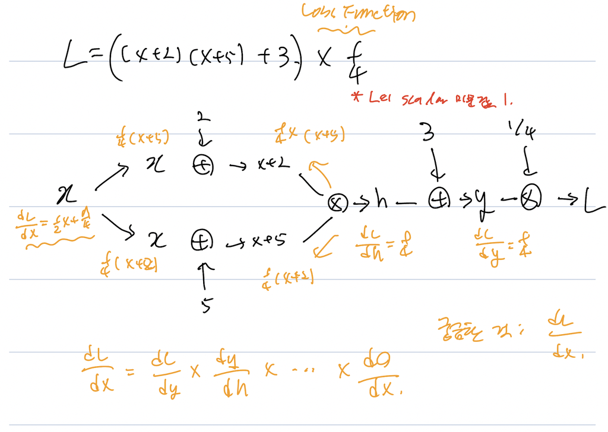

### CUDA 텐서

```python
torch.cuda.is_available()
```

```
False
```

그래픽카드 이슈로 나중에 사용하는 걸로..